# Assignment 3: BAGGING, Boosting and regressions

Hao Wang

February 07, 2017

Try trees, random forests, boosting on the usedcars.csv data.

1. Split the data into train, validate, and test subsets.
2. Do a few fits from the different approaches and see how they do on the validation data. Note, try it first with mileage and year, then try using all the x variables. Since you automatically get the right x’s as factors when you use read.csv on usedcars.csv all you have to do is y~ . and use the full data frame.
3. While you are at it, how does a multiple regression do??
4. Pick a method you like and predict on test using train and validate combined.
5. What is your out of sample RMSE???!!!

# Load Data, the larger car.csv dataset.

```r
library(tree)
library(randomForest)
library(gbm)#boosting
library(ggplot2)
mydata <- read.csv('https://raw.githubusercontent.com/ChicagoBoothML/DATA___UsedCars/master/UsedCars.csv', sep= ",")
```

# Spliting train, validation, and test

```r
names(mydata)
```

```
##  [1] "price"        "trim"         "isOneOwner"   "mileage"
##  [5] "year"         "color"        "displacement" "fuel"
##  [9] "region"       "soundSystem"  "wheelType"
```

```r
set.seed(99)
n <-nrow(mydata)
n1 <- floor(n/2) #train
n2 <- floor(n/4) #validation
n3 <- n- n1 -n2  #test
ii <- sample(1:n, n) # a funtion of sample
cartrain <- mydata[ii[1:n1],]
carval   <- mydata[ii[n1+1:n2],]
cartest  <- mydata[ii[n1 +n2 +1: n3],]
```

# Using a simple tree

To fit a simple trees, I first use CV to find the best size of tree (based on training data), then validate this tree on validation data. The first tree is based on mileage and year.

## Tree: mileage and year predicting price

```r
library(rpart)
attach(cartrain)
set.seed(99)
#--------------------------------------------------
#fit a big tree using rpart.control
big.tree = rpart(price~mileage + year,method="anova",data=cartrain,
control=rpart.control(minsplit=2,cp=.0005))
#nbig = length(unique(big.tree$where))
#cat("size of big tree: ",nbig,"\n")
#--------------------------------------------------
#look at CV results
#plotcp(big.tree)
iibest = which.min(big.tree$cptable[,"xerror"]) #which has the lowest error
bestcp=big.tree$cptable[iibest,"CP"]
bestsize = big.tree$cptable[iibest,"nsplit"]+1
cat("Best size is ", bestsize, "\n")
```

```
## Best size is  26
```

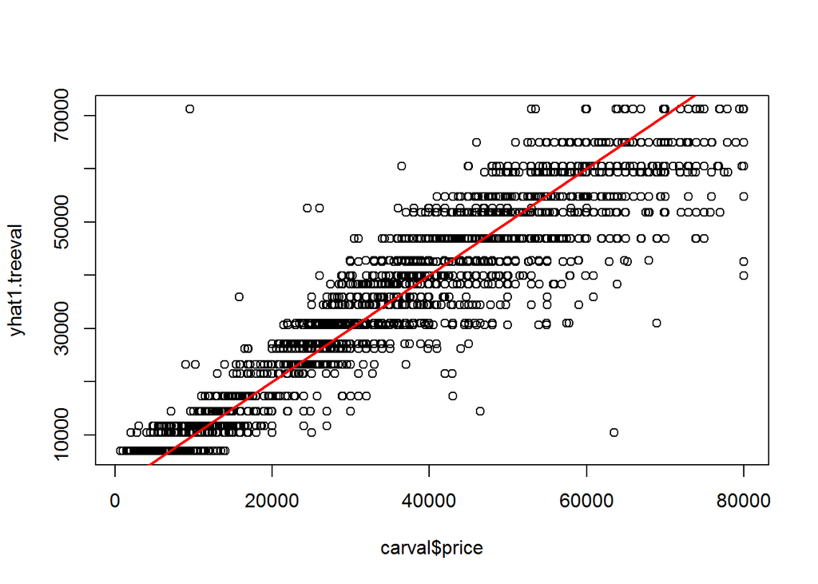

```r
#--------------------------------------------------
#prune to good tree
best.tree = prune(big.tree,cp=bestcp)
#--------------------------------------------------
#get fits
yhat1.treeval <- predict(best.tree, newdata =carval)
plot(carval$price,yhat1.treeval)
abline(0,1,col="red",lwd=2)
```

```r
cor.tree.1 <- cor(carval$price, yhat1.treeval)
cor.tree.1
```

```
## [1] 0.9533189
```

```r
detach(cartrain)
```

## Tree: price with all predictors

```r
attach(cartrain)
set.seed(99)
#--------------------------------------------------
#fit a big tree using rpart.control
big.tree = rpart(price~.,method="anova",data=cartrain,
control=rpart.control(minsplit=2,cp=.0005))
#nbig = length(unique(big.tree$where))
#cat("size of big tree: ",nbig,"\n")
#--------------------------------------------------
#look at CV results
#plotcp(big.tree)
iibest = which.min(big.tree$cptable[,"xerror"]) #which has the lowest error
bestcp=big.tree$cptable[iibest,"CP"]
bestsize = big.tree$cptable[iibest,"nsplit"]+1
cat("Best size is ", bestsize, "\n")
```

```
## Best size is  34
```

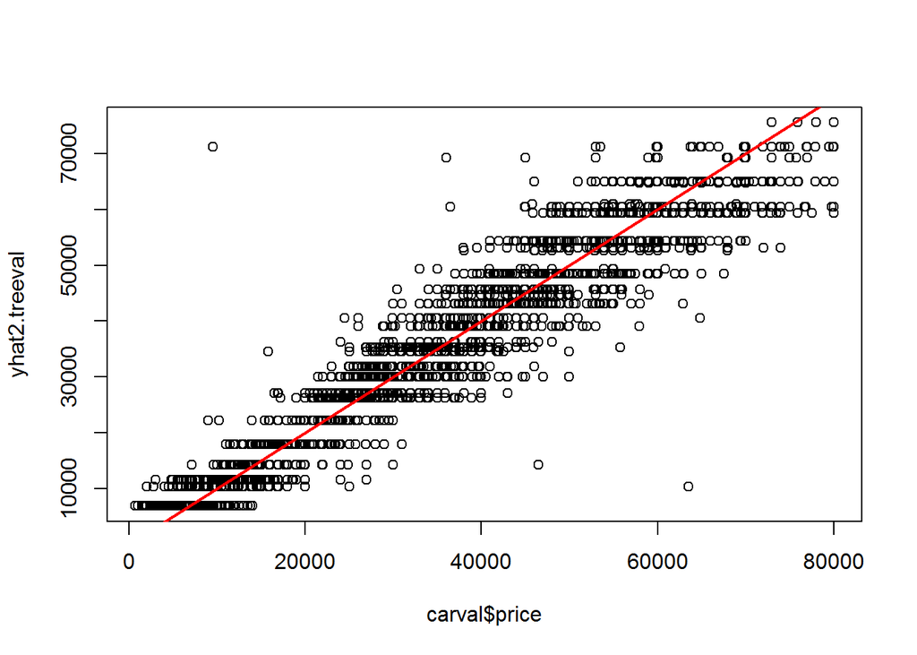

```r
#--------------------------------------------------
#prune to good tree
best.tree = prune(big.tree,cp=bestcp)
#--------------------------------------------------
#get fits
yhat2.treeval <- predict(best.tree, newdata =carval)
plot(carval$price,yhat2.treeval)
abline(0,1,col="red",lwd=2)
```

```r
cor.tree.2 <- cor(carval$price, yhat2.treeval)
cor.tree.2
```

```
## [1] 0.9653812
```

```r
detach(cartrain)
```

# Fit with random forest.

```r
attach(cartrain)
set.seed(99)
#fit using random forests (on train, predict on val)
#mtry is the number of variables to try, often we pick sqrt(p)
rffit1 = randomForest(price~ year+ mileage, data=cartrain,mtry=4,ntree=500)
yhat1.rfval = predict(rffit1,newdata=carval)# predictions on carval
rffit2 = randomForest(price~ .,data=cartrain,mtry=4,ntree=500)
yhat2.rfval = predict(rffit2,newdata=carval)
detach(cartrain)
```

# Fit with boosting.

```r
attach(cartrain)
set.seed(99)
#fit using boosting
boostfit1 = gbm(price~ year+ mileage,data=cartrain,distribution="gaussian",
interaction.depth=1,n.trees=5000,shrinkage=.01)
yhat1.boostval=predict(boostfit1,newdata=carval,n.trees=5000)

boostfit2 = gbm(price~ .,data=cartrain,distribution="gaussian",
interaction.depth=1,n.trees=5000,shrinkage=.01)
yhat2.boostval=predict(boostfit2,newdata=carval,n.trees=5000)
detach(cartrain)
```

# Plot out of sample fits

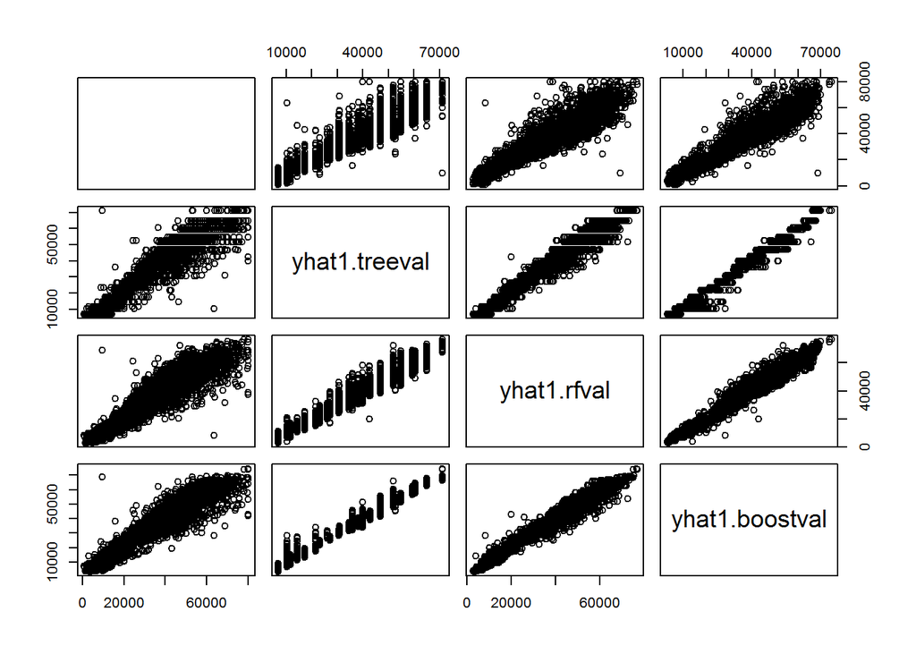

```r
pairs(cbind(carval$price,yhat1.treeval,yhat1.rfval,yhat1.boostval))
```

```r
print(cor(cbind(carval$price,yhat1.treeval,yhat1.rfval,yhat1.boostval)))
```

```
##                          yhat1.treeval yhat1.rfval yhat1.boostval
##                1.0000000     0.9533189   0.9455350      0.9581591
## yhat1.treeval  0.9533189     1.0000000   0.9821737      0.9923667
## yhat1.rfval    0.9455350     0.9821737   1.0000000      0.9846569
## yhat1.boostval 0.9581591     0.9923667   0.9846569      1.0000000
```

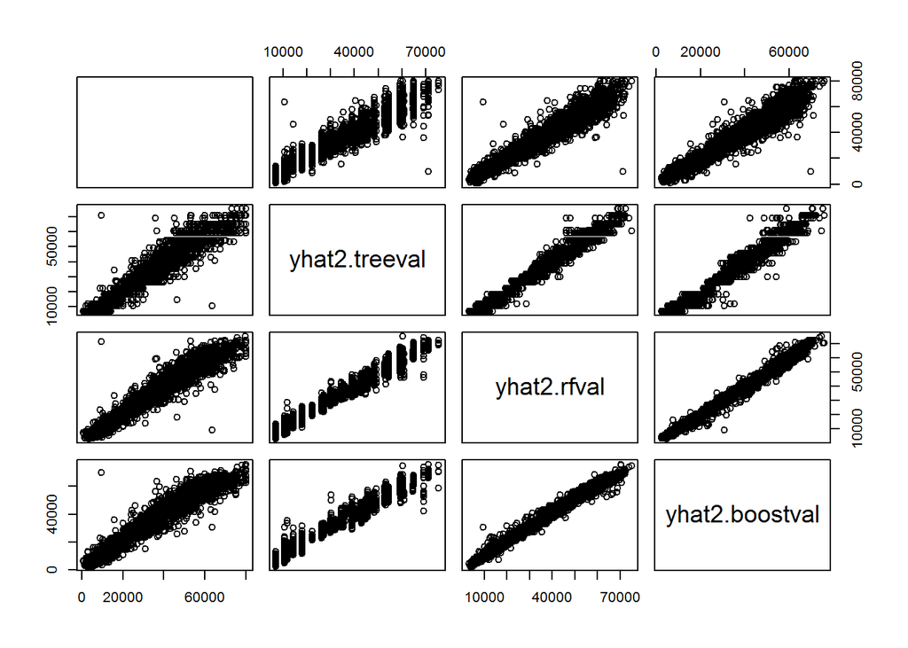

```r
#----------------------------------------------------------------
pairs(cbind(carval$price,yhat2.treeval,yhat2.rfval,yhat2.boostval))
```

```r
print(cor(cbind(carval$price,yhat2.treeval,yhat2.rfval,yhat2.boostval)))
```

```
##                          yhat2.treeval yhat2.rfval yhat2.boostval
##                1.0000000     0.9653812   0.9723256      0.9715686
## yhat2.treeval  0.9653812     1.0000000   0.9896458      0.9874270
## yhat2.rfval    0.9723256     0.9896458   1.0000000      0.9944605
## yhat2.boostval 0.9715686     0.9874270   0.9944605      1.0000000
```

# Try with linear regression

I’m comparing linear regression with boosting and random forest, as it turns out boosting and random forest fit well.

```r
attach(cartrain)
lm2 <- lm(price ~., data=cartrain)
yhat2.lmval <- predict(lm2, newdata=carval)
cor(yhat2.lmval, carval$price)
```

```
## [1] 0.9492619
```

```r
detach(cartrain)
```

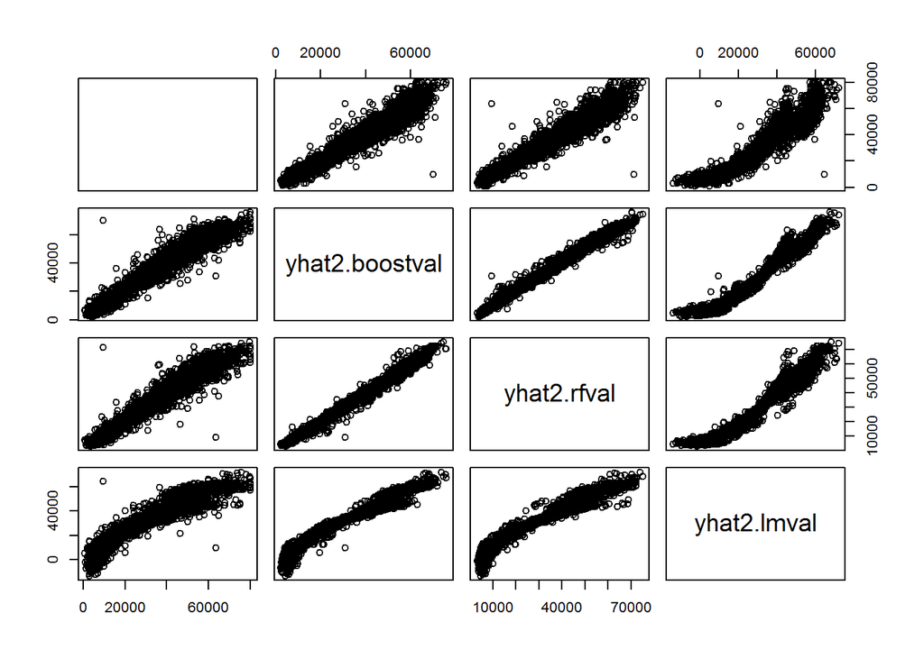

```r
pairs(cbind(carval$price,yhat2.boostval, yhat2.rfval, yhat2.lmval))
```

```r
print(cor(cbind(carval$price,yhat2.boostval, yhat2.rfval, yhat2.lmval)))
```

```
##                          yhat2.boostval yhat2.rfval yhat2.lmval
##                1.0000000      0.9715686   0.9723256   0.9492619
## yhat2.boostval 0.9715686      1.0000000   0.9944605   0.9760954
## yhat2.rfval    0.9723256      0.9944605   1.0000000   0.9727870
## yhat2.lmval    0.9492619      0.9760954   0.9727870   1.0000000
```

It seems the regression does not fit as boosting or random forest.

# Pick boosting (seems faster) and predict test with train and validation combined

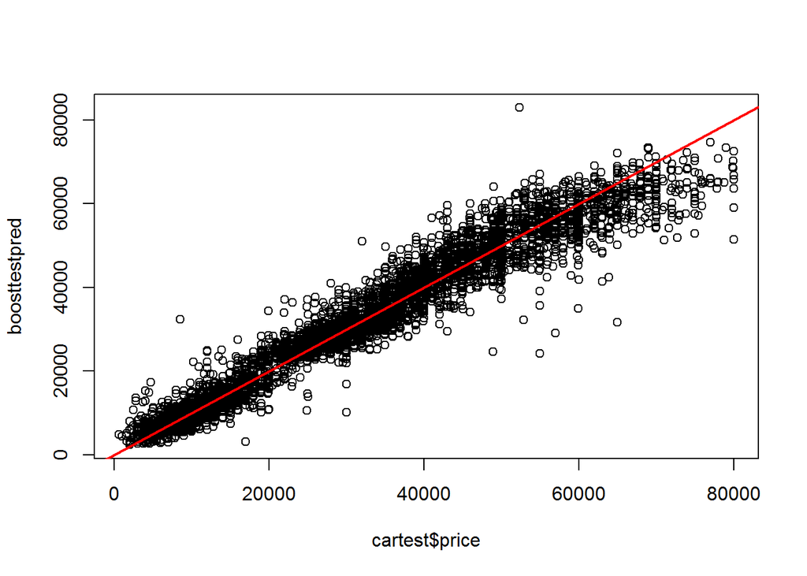

```r
cartrainval <- rbind(cartrain, carval)
set.seed(99)
#--------------------------------------------------
#refit boosting
boostfit2 = gbm(price~.,data=cartrainval,distribution="gaussian",
interaction.depth=1,n.trees=5000,shrinkage=.01)
boosttestpred=predict(boostfit2,newdata=cartest,n.trees=5000)

#--------------------------------------------------
#plot test y vs test predictions
plot(cartest$price,boosttestpred)
abline(0,1,col="red",lwd=2)
```

```r
#--------------------------------------------------
rmse = sqrt(mean((cartest$price-boosttestpred)^2))
cat("rmse on test for boosting: ",rmse,"\n")
```

```
## rmse on test for boosting:  4307.071
```

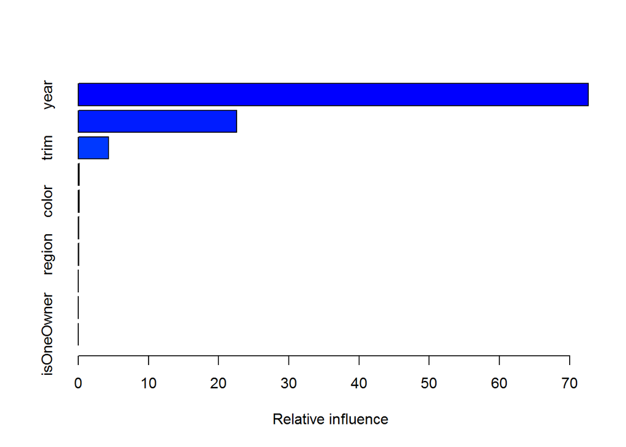

```
##                       var      rel.inf
## year                 year 7.264836e+01
## mileage           mileage 2.257798e+01
## trim                 trim 4.305723e+00
## displacement displacement 1.540533e-01
## color               color 1.373695e-01
## soundSystem   soundSystem 8.830361e-02
## region             region 7.684418e-02
## wheelType       wheelType 6.522945e-03
## fuel                 fuel 4.746667e-03
## isOneOwner     isOneOwner 9.608128e-05
```

```r
#--------------------------------------------------
#variable importance from boosting
summary(boostfit2)
```